# Study 4: Multilevel VAR(1) with Exponential Margins — Exponential vs Gaussian Marginal Models (minimal pooling)

```r
suppressPackageStartupMessages({
  library(dplyr)
  library(tidyr)
  library(readr)
  library(ggplot2)
  library(stringr)
  library(knitr)
  library(scales)
})

# Paths (consistent with Studies 1–3)
# - If you render from within `simulation_conditions/STUDY4/`, these resolve to `./data` and `./results`.
# - If you render from the project root, these fall back to `simulation_conditions/STUDY4/`.
DATA_DIR <- file.path("data")
RES_DIR  <- file.path("results")

if (!dir.exists(RES_DIR) && dir.exists(file.path("simulation_conditions", "STUDY4", "results"))) {
  DATA_DIR <- file.path("simulation_conditions", "STUDY4", "data")
  RES_DIR  <- file.path("simulation_conditions", "STUDY4", "results")
}

EXPORT_DIR <- file.path(RES_DIR, "exported_tables")
dir.create(EXPORT_DIR, showWarnings = FALSE, recursive = TRUE)

files <- list(
  design = file.path(DATA_DIR, "sim_conditions_ml.rds"),
  rep    = file.path(RES_DIR, "summary_replications_ml.csv"),
  cond   = file.path(RES_DIR, "summary_conditions_ml.csv")
)

if (!all(file.exists(unlist(files[c("rep", "cond")])))) {
  message("Missing required Study 4 inputs. Please run `run_pipeline_ml.R` and then `analysis_multilevel.R` first.")
  message("Expected files:\n- ", paste(unlist(files), collapse = "\n- "))
  if (knitr::is_html_output() || knitr::is_latex_output()) knitr::knit_exit()
}

rep_raw  <- read_csv(files$rep,  show_col_types = FALSE)
cond_raw <- read_csv(files$cond, show_col_types = FALSE)

# Optional design grid (used for design tables/labels). The report will still render without it.
design <- NULL
if (file.exists(files$design)) {
  design <- readRDS(files$design)
}

# Model labels used throughout the report
model_lab <- c(
  EG_MLmin = "EG (Exponential margins)",
  NG_MLmin = "NG (Gaussian margins)"
)

# Keep the raw summaries but standardize types where helpful.
rep_df  <- rep_raw  |> mutate(condition_id = as.integer(condition_id))
cond_df <- cond_raw |> mutate(condition_id = as.integer(condition_id))

# Fit-level table: one row per model × condition × replication.
# (Do NOT count fit statuses on the full rep_df; that would overcount by the number of parameters.)
fit_df <- rep_df |>
  distinct(model, condition_id, rep_id, status, n_div, max_rhat) |>
  mutate(model = factor(model, levels = names(model_lab), labels = unname(model_lab)))

# Attach design information (if present)
if (!is.null(design)) {
  design_aug <- design |>
    mutate(
      condition_id = as.integer(condition_id),
      N_units   = as.integer(N_units),
      T         = as.integer(T),
      burnin    = as.integer(burnin),
      rho       = as.numeric(rho),
      VARset    = as.character(VARset),
      direction = as.character(direction),
      tau_mu_1  = vapply(tau_mu, function(v) v[1], numeric(1)),
      tau_mu_2  = vapply(tau_mu, function(v) v[2], numeric(1)),
      phi11     = vapply(phi_matrix, function(M) M[1, 1], numeric(1)),
      phi12     = vapply(phi_matrix, function(M) M[1, 2], numeric(1)),
      phi21     = vapply(phi_matrix, function(M) M[2, 1], numeric(1)),
      phi22     = vapply(phi_matrix, function(M) M[2, 2], numeric(1))
    ) |>
    select(condition_id, N_units, T, burnin, rho, VARset, direction,
           tau_mu_1, tau_mu_2, phi11, phi12, phi21, phi22)

  fit_df  <- fit_df  |> left_join(design_aug, by = "condition_id")
  cond_df <- cond_df |> left_join(design_aug, by = "condition_id")
  rep_df  <- rep_df  |> left_join(design_aug, by = "condition_id")
}

# Plot theme for consistency across studies
theme_study <- function() {
  theme_minimal(base_size = 12) +
    theme(
      legend.position = "bottom",
      panel.grid.minor = element_blank(),
      axis.text.x = element_text(angle = 45, hjust = 1)
    )
}

safe_print <- function(x, msg = "(No data to display.)") {
  if (is.null(x) || (inherits(x, "data.frame") && nrow(x) == 0)) {
    cat(msg)
  } else {
    print(x)
  }
}
```

# 0. tl;dr

```
# A tibble: 2 × 5
  model                    n_fits ok_rate div_rate med_max_rhat
  <fct>                     <int>   <dbl>    <dbl>        <dbl>
1 EG (Exponential margins)     60       1    0.133         4.18
2 NG (Gaussian margins)        60       1    0             1.00
```

```
# A tibble: 2 × 3
  model                    mean_abs_bias mean_cov95
  <fct>                            <dbl>      <dbl>
1 EG (Exponential margins)        0.0283      0.848
2 NG (Gaussian margins)           0.0101      0.870
```

## 0.1 Computational diagnostics

- The table above reports per-model fit completion rates (`status == "ok"`), the fraction of completed fits with any divergent transitions, and the median of the maximum $\widehat{R}$ across parameters.
- In this multilevel setting, divergent transitions are plausibly driven by the interaction between (i) hierarchical intercepts and (ii) the lower-bound constraint used by the exponential-margin model (see Section 5.2).

## 0.2 Statistical performance

- The second table reports mean absolute bias and mean 95% coverage across parameters shared by both models: $(\Phi,\rho,\bar\mu,\tau_\mu)$.
- The marginal scale parameters are model-specific (`sigma` for NG, `sigma_exp` for EG) and should be interpreted within each margin family rather than compared directly.

## 0.3 Practical implications

- When the estimand of interest is the VAR dynamics or copula dependence, inference can be summarized primarily through $(\Phi,\rho)$, which are common to both models.
- When the estimand of interest includes innovation scale and/or tail behavior, the margin family matters; this study quantifies that sensitivity under a standardized exponential DGP.

# 1. Introduction

## 1.1 Data-generating process

For unit $i=1,\dots,N$ and time $t=2,\dots,T$, the data are generated from a bivariate VAR(1):
$$Y_{i,t} = \mu_i + \Phi Y_{i,t-1} + \epsilon_{i,t},$$
where $Y_{i,t}\in\mathbb{R}^2$, $\Phi\in\mathbb{R}^{2\times 2}$ is shared across units, and $\mu_i\in\mathbb{R}^2$ is unit-specific.

The unit intercepts follow a minimal-pooling hierarchy:
$$\mu_i \sim \mathcal{N}\!\left(\bar\mu,\; \mathrm{diag}(\tau_\mu^2)\right),$$
with $\bar\mu=(0,0)$ in the DGP and $\tau_\mu=(\tau_{\mu,1},\tau_{\mu,2})$ varying across conditions.

Innovations $\epsilon_{i,t}$ are generated using a Gaussian copula with correlation $\rho$ and exponential margins, then standardized to mean 0 and variance 1 (per margin). Specifically, if $X\sim\mathrm{Exp}(\text{scale}=s)$, then
$$Z = \frac{X-s}{s}$$
has $\mathbb{E}[Z]=0$ and $\mathrm{Var}(Z)=1$; optional mirroring produces left-skew via $-Z$.

**Note**

**Standardization and comparability** All conditions are standardized so that the marginal innovation variance is 1. Consequently, scale parameters in fitted models have truth 1 under correct specification. Deviations from 1 reflect either finite-sample error or model misspecification.

## 1.2 Simulation design

Study 4 design grid (by condition).

| condition_id | N_units | T | rho | VARset | direction | tau_mu |
| --- | --- | --- | --- | --- | --- | --- |
| 1 | 40 | 70 | 0.5 | A | ++ | (0.15, 0.15) |
| 2 | 40 | 70 | 0.5 | A | ++ | (0.40, 0.40) |

VAR coefficient matrices by VARset.

| VARset | Phi |
| --- | --- |
| A | $\begin{pmatrix} 0.40 & 0.10 \\ 0.10 & 0.40 \end{pmatrix}$ |

## 1.3 Models

Two multilevel models are fit to each simulated dataset:

- **NG_MLmin**: Gaussian margins with scale parameters `sigma[1]`, `sigma[2]` and a Gaussian copula parameter $\rho$.
- **EG_MLmin**: Exponential margins with scale parameters `sigma_exp[1]`, `sigma_exp[2]` and a Gaussian copula parameter $\rho$.

Both models share the same hierarchical intercept structure $(\bar\mu,\tau_\mu)$ and the same global VAR parameters $(\Phi,\rho)$.

# 2. Data loading and preparation

This report reads the summary artifacts produced by `run_pipeline_ml.R` and `analysis_multilevel.R` (paths shown relative to the Study 4 directory):

- `data/sim_conditions_ml.rds` (optional; simulation design table used for reporting).
- `results/summary_replications_ml.csv` (required; per-replication parameter summaries and diagnostics).
- `results/summary_conditions_ml.csv` (required; condition-level summaries: mean bias, coverage, etc.).

The replication-level file contains posterior summaries and diagnostics for each fitted dataset; the condition-level file aggregates those summaries across replications within each condition.

# 3. Computational performance

## 3.1 Fit status

Fit status counts (fit-level).

| model | status | n | prop |
| --- | --- | --- | --- |
| EG (Exponential margins) | ok | 60 | 1 |
| NG (Gaussian margins) | ok | 60 | 1 |

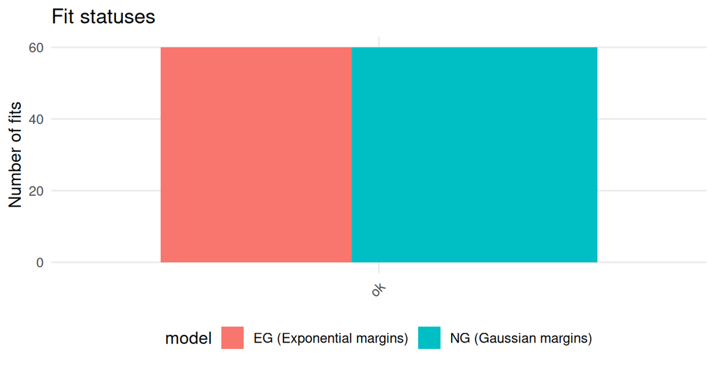

## 3.2 Divergences and $\widehat{R}$

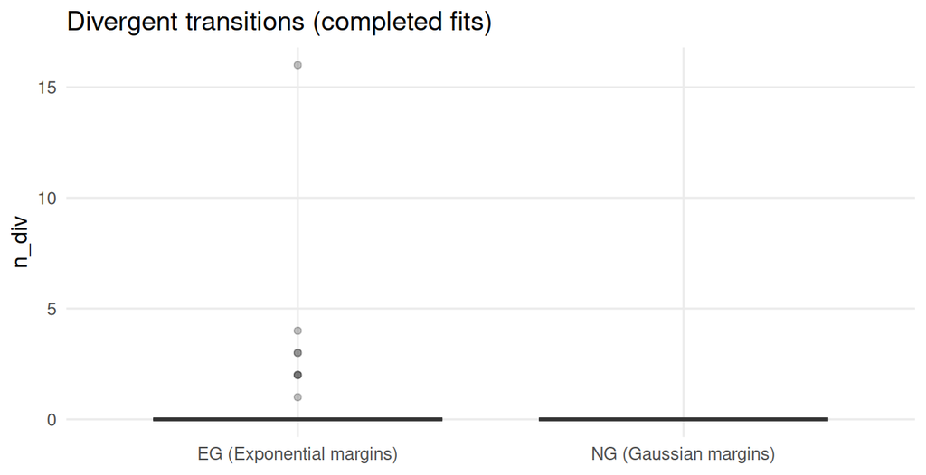

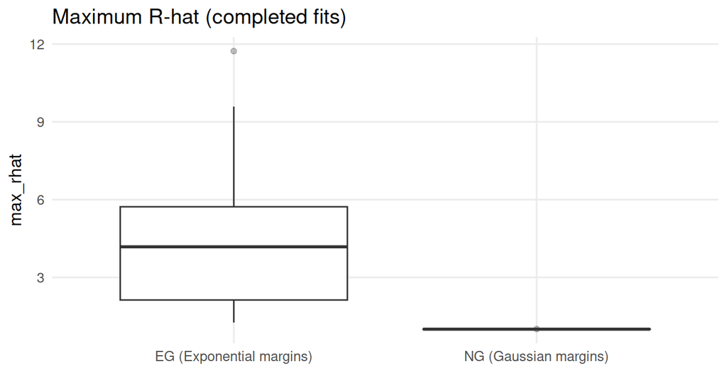

# 4. Statistical performance

Throughout, bias and coverage are computed relative to the known truth under the DGP. Condition-level summaries report:

- `mean_bias`: average posterior mean minus truth across valid replications,
- `coverage_95`: proportion of 95% credible intervals covering the truth,
- `mean_post_sd` and `emp_sd`: mean posterior SD and empirical SD of posterior means.

## 4.1 Shared global parameters $(\Phi,\rho)$

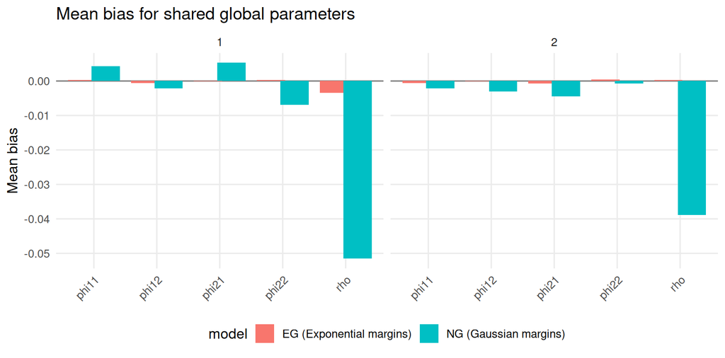

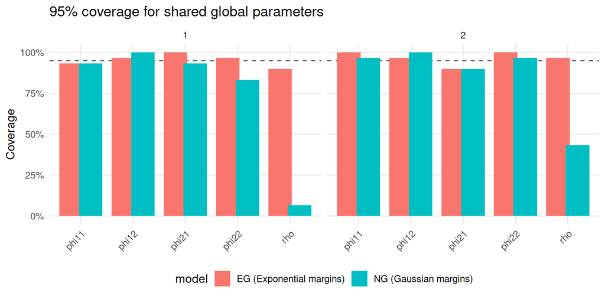

## 4.2 Marginal scale parameters

The scale parameters are defined within each margin family:

- NG: `sigma[1]`, `sigma[2]` (Gaussian margins),
- EG: `sigma_exp[1]`, `sigma_exp[2]` (exponential margins with positivity constraint).

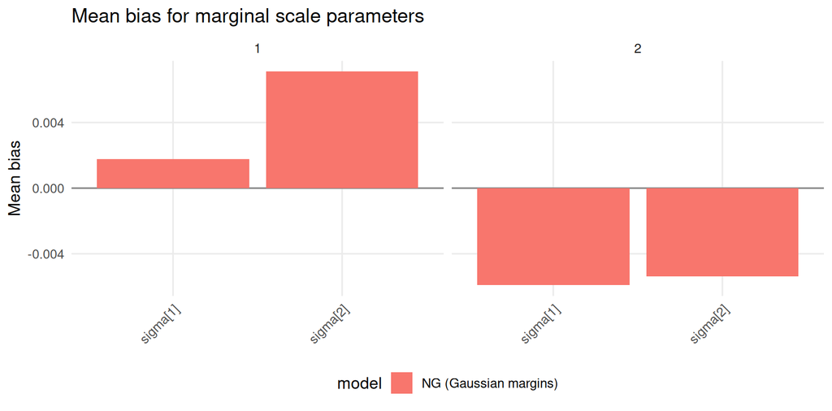

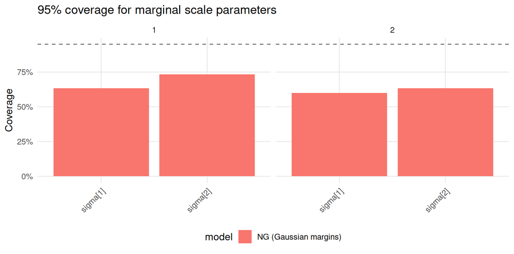

## 4.3 Hierarchical parameters $(\bar\mu,\tau_\mu)$

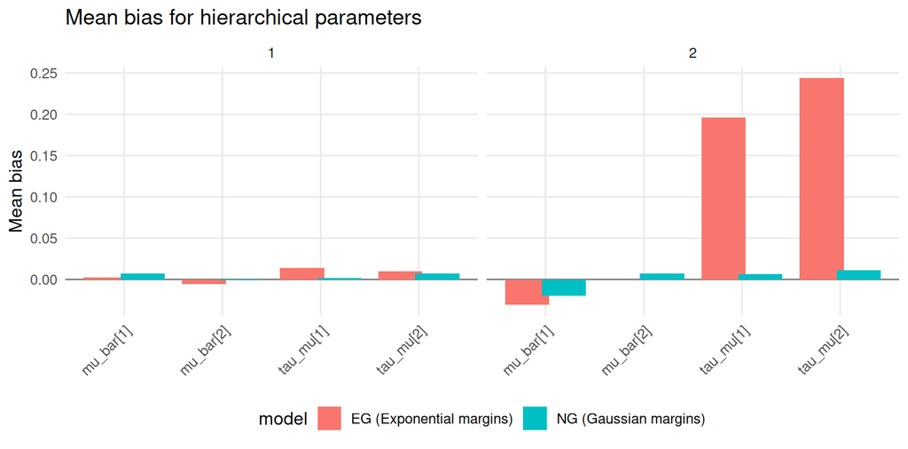

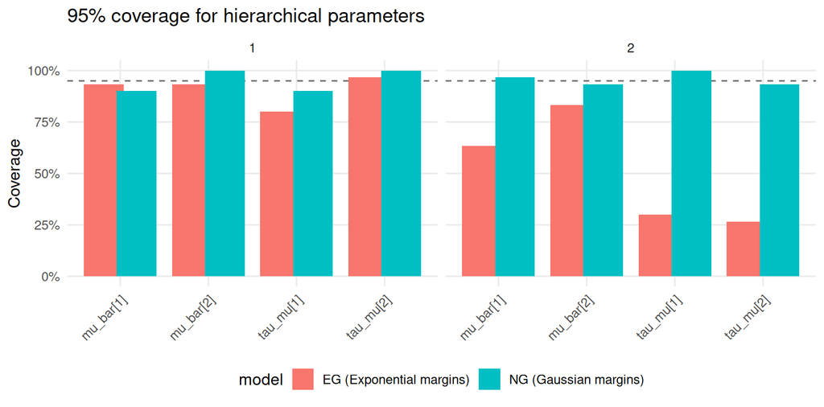

## 4.4 Unit-level intercepts $\mu_i$

Replication-level summaries may include unit-specific parameters `mu[1]` and `mu[2]` (per unit). The aggregation below summarizes unit-level bias and coverage across all unit-parameters encountered in the replication-level file.

```
(No unit-level summaries found in `summary_replications_ml.csv`.)
```

# 5. Discussion

## 5.1 Interpretation relative to the design

- Conditions differ primarily in the heterogeneity scale $\tau_\mu$ (and, depending on the design grid, may also vary in $T$, $\rho$, or $\Phi$).
- Under the exponential DGP, EG_MLmin is correctly specified for the marginal family, whereas NG_MLmin is misspecified on the margins. A common pattern under skewness is that NG_MLmin compensates via `sigma` and can distort uncertainty quantification for shared parameters under limited sample size.

## 5.2 Important caveats and recommendations

**Warning**

**Caveat: interpretation of `sigma_exp` in EG_MLmin**

The exponential-margin model enforces positivity through a data-dependent lower-bound construction:
$$x_{i,t,j} = \sigma_{\text{exp},j} + s_j\,\epsilon_{i,t,j} > 0,$$
where $s_j\in\{+1,-1\}$ encodes skew direction. Internally, $\sigma_{\text{exp},j}$ is parameterized as
$$\sigma_{\text{exp},j} = b_j + \exp(\eta_j),$$
with $b_j$ computed from the *current* residuals via a max operator. This implies:

1. `sigma_exp` is a composite of a feasibility bound and a slack term; it is not a free scale parameter in the same sense as `sigma` in the Gaussian-margin model.
2. The max-based bound can introduce non-smooth geometry in the posterior, increasing the risk of divergent transitions and sensitivity to tuning (e.g., `adapt_delta`).

**Recommendation.** When comparing models, treat `sigma` and `sigma_exp` as *within-model* diagnostics of marginal adequacy rather than as directly comparable estimands. For substantive comparisons, prioritize shared parameters $(\Phi,\rho,\bar\mu,\tau_\mu)$ and report computational diagnostics alongside inferential summaries.

**Note**

**Additional recommendations**

- If divergences are non-negligible in EG_MLmin, re-fit with higher `adapt_delta` and/or stronger regularization on $(\Phi,\rho)$ before interpreting bias/coverage.
- To isolate multilevel effects, expand the design grid in $N$ and $T$; estimation of $\tau_\mu$ is typically driven more by $N$ than by $T$.